# pandas 进阶修炼 ｜早起Python

# 4 - 数据统计描述性分析

在上一章完成基本的数据预览以及缺失值和重复值的处理后。

下一个步骤就是对数据进行简单的统计描述性分析，进一步观察数据特征。

本章就整理了部分常见操作进行练习。

## 初始化

### 设置最大显示行数和列数

```python
#行数
pd.set_option('display.max_rows', 5)

#列数
pd.set_option('display.max_columns', 5)
```

## 加载数据

```python
import pandas as pd
df = pd.read_excel("2020年中国大学排名.xlsx")
```

## 数据探索

### 1 - 查看数据

```python
df.head(2)
```

|  | 排名 | 学校名称 | 省市 | 学校类型 | ... | 社会服务得分 | 高端人才得分 | 重大项目与成果得分 | 国际竞争力得分 |
| --- | --- | --- | --- | --- | --- | --- | --- | --- | --- |
| 0 | 1 | 清华大学 | 北京 | 综合 | ... | 40.6 | 76.5 | 131.0 | 79.9 |
| 1 | 2 | 北京大学 | 北京 | 综合 | ... | 16.2 | 71.9 | 105.8 | 61.2 |

2 rows × 15 columns

### 2 - 修改索引

数据已经按照降序排列，让 学校 当索引会更好一点

-> 修改索引为 学校名称 列

```python
df.set_index("学校名称").head(2)
```

| 学校名称 | 排名 | 省市 | 学校类型 | 总分 | ... | 社会服务得分 | 高端人才得分 | 重大项目与成果得分 | 国际竞争力得分 |
| --- | --- | --- | --- | --- | --- | --- | --- | --- | --- |
| 清华大学 | 1 | 北京 | 综合 | 852.5 | ... | 40.6 | 76.5 | 131.0 | 79.9 |
| 北京大学 | 2 | 北京 | 综合 | 746.7 | ... | 16.2 | 71.9 | 105.8 | 61.2 |

2 rows × 14 columns

### 3 - 查看数据量

```python
df.shape
```

```
(100, 15)
```

### 4 - 数据排序

```python
df.sort_values("总分", ascending=False).head(3)
```

|  | 排名 | 学校名称 | 省市 | 学校类型 | ... | 社会服务得分 | 高端人才得分 | 重大项目与成果得分 | 国际竞争力得分 |
| --- | --- | --- | --- | --- | --- | --- | --- | --- | --- |
| 0 | 1 | 清华大学 | 北京 | 综合 | ... | 40.6 | 76.5 | 131.0 | 79.9 |
| 1 | 2 | 北京大学 | 北京 | 综合 | ... | 16.2 | 71.9 | 105.8 | 61.2 |
| 2 | 3 | 浙江大学 | 浙江 | 综合 | ... | 23.9 | 49.1 | 81.7 | 43.0 |

3 rows × 15 columns

### 5 - 数据排序

```python
df.sort_values("高端人才得分", ascending=False).head(3)
```

|  | 排名 | 学校名称 | 省市 | 学校类型 | ... | 社会服务得分 | 高端人才得分 | 重大项目与成果得分 | 国际竞争力得分 |
| --- | --- | --- | --- | --- | --- | --- | --- | --- | --- |
| 0 | 1 | 清华大学 | 北京 | 综合 | ... | 40.6 | 76.5 | 131.0 | 79.9 |
| 1 | 2 | 北京大学 | 北京 | 综合 | ... | 16.2 | 71.9 | 105.8 | 61.2 |
| 6 | 7 | 中国科学技术大学 | 安徽 | 理工 | ... | 0.2 | 55.1 | 49.2 | 42.2 |

3 rows × 15 columns

### 6 - 分列排名

```python
df.max()
```

```
排名              100
学校名称         首都师范大学
省市              黑龙江
学校类型             综合
总分            852.5
办学层次得分         40.0
学科水平得分         73.1
办学资源得分         39.6
师资规模与结构得分      49.2
人才培养得分        256.8
科学研究得分         81.2
社会服务得分         40.6
高端人才得分         76.5
重大项目与成果得分     131.0
国际竞争力得分        79.9
dtype: object
```

### 7 - 统计信息｜均值

计算总分列的均值

```python
df['总分'].mean()
```

```
322.5
```

### 8 - 统计信息｜中位数

计算总分列的中位数

```python
df['总分'].median()
```

```
279.65
```

### 9 - 统计信息｜众数

计算总分列的众数

```python
df['总分'].mode()
```

```
0    233.4
Name: 总分, dtype: float64
```

### 10 -统计信息｜部分

```python
print(df['总分'].min(),'  ',df['总分'].max(),'  ',df['总分'].median(),'  ',df['总分'].mode())
print(df['高端人才得分'].min(),'  ',df['高端人才得分'].max(),'  ',df['高端人才得分'].median(),'  ',df['高端人才得分'].mode())
print(df['办学层次得分'].min(),'  ',df['办学层次得分'].max(),'  ',df['办学层次得分'].median(),'  ',df['办学层次得分'].mode())
```

```
211.1    852.5    279.65    0    233.4
Name: 总分, dtype: float64
0.8    76.5    6.15    0    2.0
1    2.5
Name: 高端人才得分, dtype: float64
23.2    40.0    29.4    0    32.5
Name: 办学层次得分, dtype: float64
```

### 11 - 统计信息｜完整

查看数值型数据的统计信息（均值、分位数等），并保留两位小数

```python
pd.DataFrame(df.describe()).round(2)
```

|  | 排名 | 总分 | 办学层次得分 | 学科水平得分 | ... | 社会服务得分 | 高端人才得分 | 重大项目与成果得分 | 国际竞争力得分 |
| --- | --- | --- | --- | --- | --- | --- | --- | --- | --- |
| count | 100.00 | 100.0 | 100.00 | 100.00 | ... | 100.00 | 100.00 | 100.00 | 100.0 |
| mean | 50.49 | 322.5 | 29.69 | 27.49 | ... | 7.47 | 11.18 | 20.37 | 18.8 |
| ... | ... | ... | ... | ... | ... | ... | ... | ... | ... |
| 75% | 75.25 | 378.8 | 31.90 | 33.92 | ... | 9.80 | 12.35 | 24.78 | 21.0 |
| max | 100.00 | 852.5 | 40.00 | 73.10 | ... | 40.60 | 76.50 | 131.00 | 79.9 |

8 rows × 12 columns

### 12 - 统计信息｜分组

计算各省市总分均值

```python
df.groupby('省市').mean()['总分'].round(2)
```

```
省市
上海     350.51
云南     234.10
北京     362.83
吉林     326.00
四川     349.27
天津     396.20
安徽     328.70
山东     304.63
广东     286.01
江苏     298.39
江西     228.40
河北     216.70
河南     223.90
浙江     335.15
湖北     335.09
湖南     320.10
甘肃     300.40
福建     313.55
辽宁     339.55
重庆     289.20
陕西     297.69
黑龙江    364.80
Name: 总分, dtype: float64
```

### 13 - 统计信息｜相关系数

也就是相关系数矩阵，也就是每两列之间的相关性系数

```python
df.corr().round(2)
```

|  | 排名 | 总分 | ... | 重大项目与成果得分 | 国际竞争力得分 |
| --- | --- | --- | --- | --- | --- |
| 排名 | 1.00 | -0.85 | ... | -0.73 | -0.69 |
| 总分 | -0.85 | 1.00 | ... | 0.95 | 0.92 |
| ... | ... | ... | ... | ... | ... |
| 重大项目与成果得分 | -0.73 | 0.95 | ... | 1.00 | 0.88 |
| 国际竞争力得分 | -0.69 | 0.92 | ... | 0.88 | 1.00 |

12 rows × 12 columns

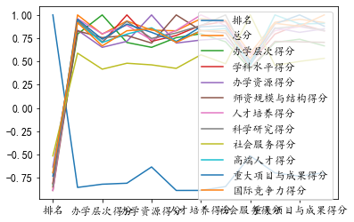

```python
import matplotlib.pyplot as plt


plt.rcParams['font.sans-serif'] = ['KaiTi', 'SimHei', 'FangSong']  # 汉字字体,优先使用楷体，如果找不到楷体，则使用黑体
plt.rcParams['font.size'] = 12  # 字体大小
plt.rcParams['axes.unicode_minus'] = False  # 正常显示负号


pd.DataFrame(df.corr()).plot()
plt.show()
```

### 15 - 统计信息｜频率

计算各省市出现的次数

```python
df['省市'].value_counts()
```

```
北京    18
江苏    15
      ..
江西     1
河北     1
Name: 省市, Length: 22, dtype: int64
```

### 17 - 统计信息｜直方图

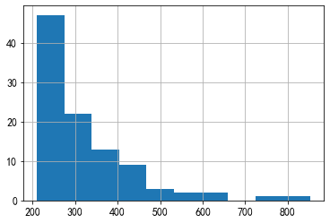

```python
df['总分'].hist()
plt.show()
```